# model-zero-inflated-microbiome

David Xin Zhao

2022-11-28

## Load useful libraries

```r
library(tidyverse) # data manipulation and visualizations
library(pscl)  # implement ZIP, ZINB, ZHP, and ZHNB models
library(Maaslin2) # provides microbiome and meta data sets
library(readr)
library(vegan)
library(lmtest)
library(nonnest2)
```

## Procedure at a glance

1. Load abundance data and prepare analysis abundance
2. Investigate outcome distribution zeros
3. Create offset for Poisson/ NB models (to calculate ratios)
4. Create a formula for fitting ZIP/ ZINB and ZHP/ ZHNB
5. Fit ZIP/ ZINB and ZHP/ ZHNB
6. Select the optimal model
7. Interpret models’ output

## Step 1 Preprocess data for downstream modeling

The 16S abundance data and metadata was retrieved from the [Inflammatory Bowel Disease Multi’omics Database] (https://ibdmdb.org/tunnel/public/HMP2/16S/1806/products).

```r
# read in 16S abundance/ count data in HMP2 database
untar("hmp2_abund.tar", exdir = getwd()) # unzip a .tar file

abund_raw <- read_tsv("taxonomic_profiles.tsv.gz",
                      show_col_types = FALSE) %>%
        as.data.frame()
```

Read in the metadata in `.csv` format.

```r
# read in the meta data
meta_raw <- read.csv("hmp2_metadata.csv")
```

Subset identifiers, environmental/ clinical variables of my research interest, including `Project`, `External.ID`, `Participant.ID`, `week_num`, `biopsy_location`, `diagnosis` and `Age.at.diagnosis`.

```r
meta_raw_sub <- meta_raw %>%
        select(Project,
               External.ID,
               Participant.ID,
               diagnosis,
               week_num,
               biopsy_location,
               Age.at.diagnosis)
```

Merge 16S abundance data and subset metadata.

```r
# reshape abundance data
abund_raw_id <- abund_raw %>%
        gather(key="sample_id",
               value = "read",
               -c("#OTU ID", "taxonomy"))

# join two data frames by "id" = "External.ID"
abund_meta <- abund_raw_id %>%
        inner_join(meta_raw_sub,
                   by = c("sample_id" = "External.ID"))
```

The microbiome 16S abundance data set contains data points from 81 participants; the biopsy were collected from 7 different locations, including `Rectum`, `Ileum`, `Sigmoid Colon`, `Descending (left-sided) colon`, `Cecum`, `Ascending (right-sided) colon`, and `Transverse colon`. For the simplicity purpose, I focused on rectum biopsy data for the subsequent analysis.

```r
abund_meta_rectum <- abund_meta %>%
        filter(biopsy_location == "Rectum")
```

Collapse taxonomy at the genus level, namely similarity equals or higher than 97%

```r
abund_meta_rectum2 <- abund_meta_rectum %>%
        mutate(genus = str_split_fixed(abund_meta_rectum$taxonomy, "; __", 6)[,6]) %>%
        mutate(genus_rep = case_when(genus == "g" ~ "unclassified",
                                     genus != "g" ~ genus)) %>%
        select(-genus)
```

Select columns, `sample_id`, `Project`, `Participant.ID`, `read`, `diagnosis` and `genus_rep` from the above data frame. And then calculate total reads for each individual as the offset.

```r
abund_meta_rectum3 <- abund_meta_rectum2 %>%
        select(sample_id, Participant.ID, read, diagnosis, genus_rep) %>%
        rename(subject_id = Participant.ID)

df_total_reads <- abund_meta_rectum3 %>%
        group_by(sample_id) %>%
        summarise(lib_size = sum(read)) %>%
        ungroup()

abund_meta_rectum4 <- abund_meta_rectum3 %>%
        left_join(df_total_reads, by="sample_id")


# convert to the factor variable with new levels
abund_meta_rectum4$diagnosis <- factor(abund_meta_rectum4$diagnosis,
                                       levels = c("nonIBD", "CD", "UC"))


# abund_meta_rectum3 %>%
#         group_by(sample_id) %>%
#         summarise(lib_size= sum(read)) %>%
#         arrange(lib_size) %>%
#         ggplot(aes(x=1, y=lib_size)) +  # visualize distribution of variations in library sizes
#         geom_jitter()+
#         scale_y_log10()
```

The sampling depth varied by samples which likely affect hypothesis analysis. I consider to choose a best depth threshold and to conduct rarefaction, following the [instruction] (https://www.youtube.com/watch?v=c7H8jLjTxSE) introduced by Dr. Pat Schloss. The optimal sampling depth threshold is determined according to the good’s coverage statistics.

```r
# abund_meta_rectum3 %>%
#         group_by(sample_id) %>%
#         summarise(singles = sum(read == 1),
#                   lib_size = sum(read)) %>%
#         mutate(goods_cov = 100*(1-singles/lib_size)) %>%  # calculate the good's coverage
#         ggplot(aes(x= lib_size, y=goods_cov))+ # plot sampling size by goods coverage
#         geom_point() +
#         geom_hline(yintercept = 97, color = "red")  # good's coverage = 97 percentage
#
#
# abund_meta_rectum3_goods <- abund_meta_rectum3 %>%
#         group_by(sample_id) %>%
#         summarise(singles = sum(read == 1),
#                   lib_size = sum(read)) %>%
#         mutate(goods_cov = 100*(1-singles/lib_size))
#
#
# abund_meta_rectum3_goods %>%
#         filter(goods_cov >= 97) %>%
#         arrange(lib_size)  # sampling depth threshold = 286 reads
#
#
# # identify ids for samples below the minimal sampling depth
# sample_drop <- abund_meta_rectum3_goods %>%
#         filter(goods_cov <97)  %>%
#         pull(sample_id)
#
```

## Step 2 Investigate outcome distribution zeros

Subset samples with zero percentage higher ranging from 50% to close 100%. Apply models specializing in the zero-inflated data to the sub-samples.

```r
df_zero_percent <- abund_meta_rectum4 %>%
        filter(genus_rep != "unclassified") %>%
        group_by(genus_rep) %>%
        summarise(zero_percent = mean(read == 0))

df_zero_percent$zero_cut <- cut(df_zero_percent$zero_percent, breaks = 4)  # cut zero_percentage into four groups

levels(df_zero_percent$zero_cut)
```

```
## [1] "(0.0102,0.258]" "(0.258,0.506]"  "(0.506,0.753]"  "(0.753,1]"
```

```r
# subset variables for the genus with many zero
abund_meta_rectum5 <- abund_meta_rectum4 %>%
        left_join(df_zero_percent, by= "genus_rep") %>%
        arrange(desc(zero_percent))
```

Create histogram for representative genus, `_Clostridium_innocuum_group` with excessive zeros

```r
abund_meta_rectum5 %>%
        filter(zero_percent != 1) %>%
        filter(zero_cut == "(0.506,0.753]") %>%
        head(10)
```

```
##    sample_id subject_id read diagnosis                   genus_rep lib_size
## 1     206646      C3016    0        CD _Clostridium_innocuum_group    23607
## 2     206646      C3016    9        CD _Clostridium_innocuum_group    23607
## 3     224324      H4045    0    nonIBD _Clostridium_innocuum_group    23232
## 4     224324      H4045    0    nonIBD _Clostridium_innocuum_group    23232
## 5     206619      C3002    0        CD _Clostridium_innocuum_group     3220
## 6     206619      C3002    0        CD _Clostridium_innocuum_group     3220
## 7     224326      H4044    0        UC _Clostridium_innocuum_group    29862
## 8     224326      H4044    2        UC _Clostridium_innocuum_group    29862
## 9     206624      C3004    0        UC _Clostridium_innocuum_group      716
## 10    206624      C3004    0        UC _Clostridium_innocuum_group      716
##    zero_percent      zero_cut
## 1      0.747191 (0.506,0.753]
## 2      0.747191 (0.506,0.753]
## 3      0.747191 (0.506,0.753]
## 4      0.747191 (0.506,0.753]
## 5      0.747191 (0.506,0.753]
## 6      0.747191 (0.506,0.753]
## 7      0.747191 (0.506,0.753]
## 8      0.747191 (0.506,0.753]
## 9      0.747191 (0.506,0.753]
## 10     0.747191 (0.506,0.753]
```

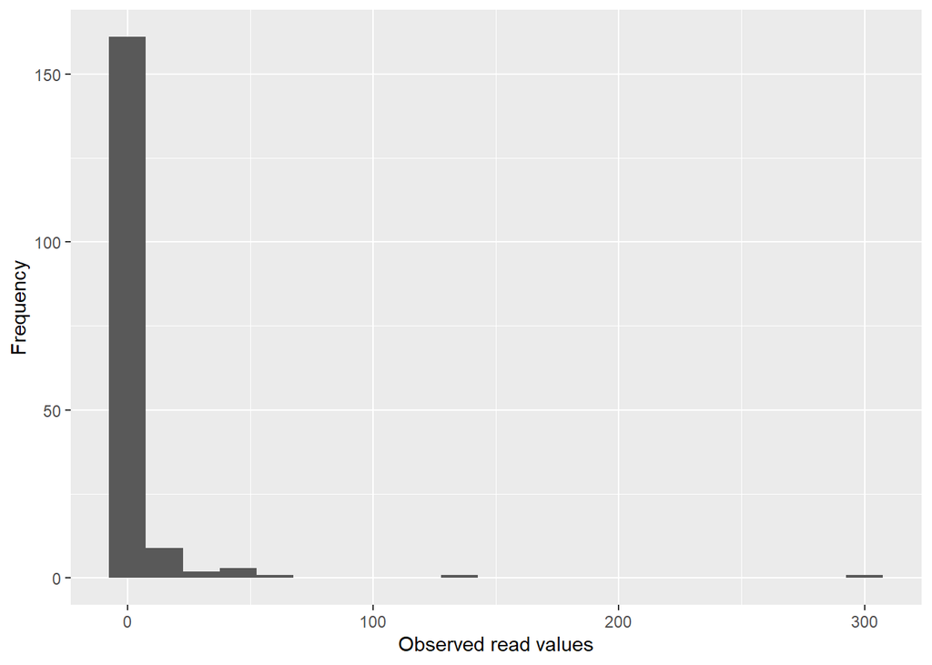

```r
# use "_Clostridium_innocuum_group" as an example for plotting histogram
abund_meta_rectum5 %>%
        filter(genus_rep == "_Clostridium_innocuum_group") %>%
        ggplot(aes(x=read))+
         geom_histogram(binwidth = 15)+
        xlab("Observed read values")+
        ylab("Frequency")
```

## Step 3 Create offset for poisson/ NB models to calculate ratios

The total count reads is used to calculate offset. The offset will be adjusted as a covariate in the model later to ensure microbiome response is relative abundance instead of count data.

This step is critical in fitting linear mixed effects modesl in microbiome study.

```r
abund_meta_rectum6 <- abund_meta_rectum5 %>%
        mutate(Offset =  log(lib_size)) %>%
        filter(genus_rep == "_Clostridium_innocuum_group")

head(abund_meta_rectum6$Offset)  # view first rows
```

```
## [1] 10.069299 10.069299 10.053286 10.053286  8.077137  8.077137
```

## Step 4 Create a formula for fitting ZIP/ ZINB and ZHP/ ZHNB

The formula can be used to specify both components of the model pertaining to count and structural zero models.

To illustrate more features of zero-inflated and zero-hurdle models and to compare these features, in the following analysis, I choose the same covariate for both count and binomial distribution, but only set offset argument to count component.

```r
f_model <- formula(read ~ diagnosis + offset(Offset) | diagnosis)
```

## Step 5 Fit ZIP/ ZINB and ZHP/ ZHNB

Fit a ZIP model for the representative taxa `_Clostridium_innocuum_group` as the function of `diagnosis`, indicating `nonIBD` versus `UC` versus `CD`.

Use `zeroinfl()` function of `pscl` package to fit ZIP model.

```r
ZIP_innocuum <- zeroinfl(formula = f_model,
                         dist = "poisson",
                         link = "logit",
                         data = abund_meta_rectum6)
```

In above formula, the `dist` option specifies the distribution for the count data. Currently, Poisson negative binomial, and geometric distribution are available in `pscl` package.

The `link = logit` option specifies the logistic link for the structural zeros versus non-structural zeros (the sampling zeros plus the positive counts).

The `offset` term (the log of the total reads in a given sample) is used here to allow for a comparison in the relative abundance (and not absolute counts) among groups.

```r
summary(ZIP_innocuum)
```

```
##
## Call:
## zeroinfl(formula = f_model, data = abund_meta_rectum6, dist = "poisson",
##     link = "logit")
##
## Pearson residuals:
##      Min       1Q   Median       3Q      Max
##  -0.7181  -0.6139  -0.4972  -0.2743 109.3456
##
## Count model coefficients (poisson with log link):
##             Estimate Std. Error z value Pr(>|z|)
## (Intercept)  -7.6948     0.1171 -65.704   <2e-16 ***
## diagnosisCD   1.2164     0.1236   9.839   <2e-16 ***
## diagnosisUC   0.3522     0.1408   2.503   0.0123 *
##
## Zero-inflation model coefficients (binomial with logit link):
##             Estimate Std. Error z value Pr(>|z|)
## (Intercept)   1.2831     0.3780   3.394 0.000689 ***
## diagnosisCD  -0.3595     0.4554  -0.789 0.429920
## diagnosisUC  -0.6983     0.5059  -1.380 0.167482
## ---
## Signif. codes:  0 '***' 0.001 '**' 0.01 '*' 0.05 '.' 0.1 ' ' 1
##
## Number of iterations in BFGS optimization: 10
## Log-likelihood: -1264 on 6 Df
```

The row `BFGS optimization` refers to the number of optimal iterations. `diagnosisCD` and `diagnosisUC` are significant for poisson with log link function alone. Note ZIP model assumes that no over-dispersion in the non-zero count data.

Below fit ZINB model alternatively.

```r
ZINB_innocuum <- zeroinfl(formula = f_model,
                          dist = "negbin",
                          link="logit",
                          data= abund_meta_rectum6)


# print ZINB output
summary(ZINB_innocuum)
```

```
##
## Call:
## zeroinfl(formula = f_model, data = abund_meta_rectum6, dist = "negbin",
##     link = "logit")
##
## Pearson residuals:
##     Min      1Q  Median      3Q     Max
## -0.3105 -0.2811 -0.2420 -0.2037  9.1196
##
## Count model coefficients (negbin with log link):
##             Estimate Std. Error z value Pr(>|z|)
## (Intercept)  -6.2744     0.7793  -8.052 8.16e-16 ***
## diagnosisCD  -1.1295     0.8637  -1.308    0.191
## diagnosisUC  -1.9110     0.9210  -2.075    0.038 *
## Log(theta)   -2.3275     0.3054  -7.622 2.50e-14 ***
##
## Zero-inflation model coefficients (binomial with logit link):
##             Estimate Std. Error z value Pr(>|z|)
## (Intercept)   0.0387     0.7520   0.051    0.959
## diagnosisCD  -1.6342     1.6276  -1.004    0.315
## diagnosisUC  -9.7720    83.9639  -0.116    0.907
## ---
## Signif. codes:  0 '***' 0.001 '**' 0.01 '*' 0.05 '.' 0.1 ' ' 1
##
## Theta = 0.0975
## Number of iterations in BFGS optimization: 70
## Log-likelihood: -256.5 on 7 Df
```

The `Log(theta)` value indicates that data are over-dispersed.

Use the same formula and offset as fitting ZIP and ZINB models above to fit ZHP and ZHNB models using the function `hurdle()` from the `pscl` package.

```r
ZHP_innocuum <- hurdle(formula = f_model,
                       dist = "poisson",
                       data = abund_meta_rectum6)

summary(ZHP_innocuum)
```

```
##
## Call:
## hurdle(formula = f_model, data = abund_meta_rectum6, dist = "poisson")
##
## Pearson residuals:
##     Min      1Q  Median      3Q     Max
## -0.6563 -0.5738 -0.5071 -0.4314 71.2298
##
## Count model coefficients (truncated poisson with log link):
##             Estimate Std. Error z value Pr(>|z|)
## (Intercept)  -7.7011     0.1174 -65.586   <2e-16 ***
## diagnosisCD   1.2251     0.1239   9.887   <2e-16 ***
## diagnosisUC   0.3622     0.1410   2.569   0.0102 *
## Zero hurdle model coefficients (binomial with logit link):
##             Estimate Std. Error z value Pr(>|z|)
## (Intercept)  -1.4137     0.3717  -3.804 0.000143 ***
## diagnosisCD   0.3459     0.4463   0.775 0.438418
## diagnosisUC   0.5870     0.4907   1.196 0.231616
## ---
## Signif. codes:  0 '***' 0.001 '**' 0.01 '*' 0.05 '.' 0.1 ' ' 1
##
## Number of iterations in BFGS optimization: 13
## Log-likelihood: -1269 on 6 Df
```

Alternatively, fit ZHNB model with identical formula and offset.

```r
ZHNB_innocuum <- hurdle(formula = f_model,
                        dist = "negbin",
                        data = abund_meta_rectum6)


summary(ZHNB_innocuum)
```

```
##
## Call:
## hurdle(formula = f_model, data = abund_meta_rectum6, dist = "negbin")
##
## Pearson residuals:
##     Min      1Q  Median      3Q     Max
## -0.6373 -0.2733 -0.2224 -0.1766  6.1081
##
## Count model coefficients (truncated negbin with log link):
##             Estimate Std. Error z value Pr(>|z|)
## (Intercept)  -14.448     70.128  -0.206    0.837
## diagnosisCD   -1.051      1.045  -1.005    0.315
## diagnosisUC   -2.103      1.091  -1.927    0.054 .
## Log(theta)   -10.829     70.127  -0.154    0.877
## Zero hurdle model coefficients (binomial with logit link):
##             Estimate Std. Error z value Pr(>|z|)
## (Intercept)  -1.4137     0.3717  -3.804 0.000143 ***
## diagnosisCD   0.3459     0.4463   0.775 0.438418
## diagnosisUC   0.5870     0.4907   1.196 0.231616
## ---
## Signif. codes:  0 '***' 0.001 '**' 0.01 '*' 0.05 '.' 0.1 ' ' 1
##
## Theta: count = 0
## Number of iterations in BFGS optimization: 117
## Log-likelihood: -261.7 on 7 Df
```

## Step 6 Select the optimal model

Compare four models, `ZIP_innocuum`, `ZINB_innocuum`, `ZHP_innocuum`, and `ZHNB_innocuum` based on alternative statsitics (i.e., likelihood ratio, AIC, BIC and Vuong test).

Use `lmtest` and `nonnest2` packages for statistics computation.

```r
# likelihood
lmtest::lrtest(ZIP_innocuum, ZINB_innocuum)
```

```
## Likelihood ratio test
##
## Model 1: read ~ diagnosis + offset(Offset) | diagnosis
## Model 2: read ~ diagnosis + offset(Offset) | diagnosis
##   #Df  LogLik Df  Chisq Pr(>Chisq)
## 1   6 -1264.0
## 2   7  -256.5  1 2015.1  < 2.2e-16 ***
## ---
## Signif. codes:  0 '***' 0.001 '**' 0.01 '*' 0.05 '.' 0.1 ' ' 1
```

```r
lmtest::lrtest(ZHP_innocuum, ZHNB_innocuum)
```

```
## Likelihood ratio test
##
## Model 1: read ~ diagnosis + offset(Offset) | diagnosis
## Model 2: read ~ diagnosis + offset(Offset) | diagnosis
##   #Df   LogLik Df  Chisq Pr(>Chisq)
## 1   6 -1269.08
## 2   7  -261.75  1 2014.7  < 2.2e-16 ***
## ---
## Signif. codes:  0 '***' 0.001 '**' 0.01 '*' 0.05 '.' 0.1 ' ' 1
```

```r
# AIC
t(AIC(ZIP_innocuum, ZINB_innocuum, ZHP_innocuum, ZHNB_innocuum)) # lower is better
```

```
##     ZIP_innocuum ZINB_innocuum ZHP_innocuum ZHNB_innocuum
## df         6.000        7.0000        6.000        7.0000
## AIC     2540.085      526.9932     2550.154      537.4934
```

```r
# BIC
nonnest2::icci(ZIP_innocuum, ZINB_innocuum, conf.level = 0.95)
```

```
##
## Model 1
##  Class: zeroinfl
##  Call: zeroinfl(formula = f_model, data = abund_meta_rectum6, dist = "poisson", ...
##  AIC: 2540.085
##  BIC: 2559.176
##
## Model 2
##  Class: zeroinfl
##  Call: zeroinfl(formula = f_model, data = abund_meta_rectum6, dist = "negbin", ...
##  AIC: 526.993
##  BIC: 549.266
##
## 95% Confidence Interval of AIC difference (AICdiff = AIC1 - AIC2)
##   493.013 < AICdiff < 3533.170
##
## 95% Confidence Interval of BIC difference (BICdiff = BIC1 - BIC2)
##   489.832 < BICdiff < 3529.988
```

```r
nonnest2::icci(ZHP_innocuum, ZHNB_innocuum)
```

```
##
## Model 1
##  Class: hurdle
##  Call: hurdle(formula = f_model, data = abund_meta_rectum6, dist = "poisson")
##  AIC: 2550.154
##  BIC: 2569.245
##
## Model 2
##  Class: hurdle
##  Call: hurdle(formula = f_model, data = abund_meta_rectum6, dist = "negbin")
##  AIC: 537.493
##  BIC: 559.766
##
## 95% Confidence Interval of AIC difference (AICdiff = AIC1 - AIC2)
##   494.424 < AICdiff < 3530.898
##
## 95% Confidence Interval of BIC difference (BICdiff = BIC1 - BIC2)
##   491.243 < BICdiff < 3527.716
```

```r
# Vuong test
vuong(ZIP_innocuum, ZHP_innocuum)
```

```
## Vuong Non-Nested Hypothesis Test-Statistic:
## (test-statistic is asymptotically distributed N(0,1) under the
##  null that the models are indistinguishible)
## -------------------------------------------------------------
##               Vuong z-statistic             H_A   p-value
## Raw                    2.876348 model1 > model2 0.0020115
## AIC-corrected          2.876348 model1 > model2 0.0020115
## BIC-corrected          2.876348 model1 > model2 0.0020115
```

```r
vuong(ZIP_innocuum, ZHNB_innocuum)
```

```
## Vuong Non-Nested Hypothesis Test-Statistic:
## (test-statistic is asymptotically distributed N(0,1) under the
##  null that the models are indistinguishible)
## -------------------------------------------------------------
##               Vuong z-statistic             H_A   p-value
## Raw                   -2.576301 model2 > model1 0.0049932
## AIC-corrected         -2.576301 model2 > model1 0.0049932
## BIC-corrected         -2.576301 model2 > model1 0.0049932
```

```r
vuong(ZINB_innocuum, ZHP_innocuum)
```

```
## Vuong Non-Nested Hypothesis Test-Statistic:
## (test-statistic is asymptotically distributed N(0,1) under the
##  null that the models are indistinguishible)
## -------------------------------------------------------------
##               Vuong z-statistic             H_A   p-value
## Raw                    2.608116 model1 > model2 0.0045521
## AIC-corrected          2.608116 model1 > model2 0.0045521
## BIC-corrected          2.608116 model1 > model2 0.0045521
```

```r
vuong(ZINB_innocuum, ZHNB_innocuum)
```

```
## Vuong Non-Nested Hypothesis Test-Statistic:
## (test-statistic is asymptotically distributed N(0,1) under the
##  null that the models are indistinguishible)
## -------------------------------------------------------------
##               Vuong z-statistic             H_A   p-value
## Raw                    2.932639 model1 > model2 0.0016805
## AIC-corrected          2.932639 model1 > model2 0.0016805
## BIC-corrected          2.932639 model1 > model2 0.0016805
```

```r
vuong(ZHNB_innocuum, ZHP_innocuum)
```

```
## Vuong Non-Nested Hypothesis Test-Statistic:
## (test-statistic is asymptotically distributed N(0,1) under the
##  null that the models are indistinguishible)
## -------------------------------------------------------------
##               Vuong z-statistic             H_A   p-value
## Raw                    2.593506 model1 > model2 0.0047501
## AIC-corrected          2.593506 model1 > model2 0.0047501
## BIC-corrected          2.593506 model1 > model2 0.0047501
```